# The Seasonal Demographic Pulse: Temporal Volatility in U.S. County Demographics

Detecting Cyclical Patterns in Population Components Using Time Series Analysis

Census Monkey Typewriter

2025-07-09

# Executive Summary

America’s demographic landscape pulses with seasonal rhythms that extend far beyond simple population counts. This analysis explores how U.S. counties exhibit temporal volatility in their fundamental demographic components—births, deaths, and migration—using sophisticated time series analysis of Population Estimates Program data from 2015-2019.

Our investigation reveals that demographic volatility is not randomly distributed but follows predictable patterns tied to economic structure, geographic location, and seasonal population flows. Counties dependent on vacation homes, seasonal agriculture, and tourism experience dramatically higher volatility in their demographic profiles, creating what we term a “seasonal demographic pulse.”

This research introduces new methods for detecting and measuring demographic seasonality using Census data, with implications for service planning, infrastructure investment, and understanding America’s evolving settlement patterns.

# The Concept of Demographic Seasonality

## Beyond Population Counts: The Components of Change

Traditional demographic analysis focuses on annual population totals, missing the underlying volatility in births, deaths, and migration that drives population change. Our approach examines the temporal patterns in these components to identify counties experiencing significant seasonal demographic pulses.

## Measuring Demographic Volatility

We develop several metrics to capture temporal instability in demographic components:

**Birth Volatility**: Coefficient of variation in annual births (2015-2019) **Death Volatility**: Coefficient of variation in annual deaths (2015-2019)  
**Migration Volatility**: Coefficient of variation in net migration (2015-2019) **Total Volatility**: Combined measure of all components

Counties are classified into demographic pulse categories based on their volatility patterns:

Demographic Volatility Patterns Across U.S. Counties

| volatility_type | n_counties | avg_birth_volatility | avg_death_volatility | avg_mig_volatility | avg_total_volatility | avg_population |
| --- | --- | --- | --- | --- | --- | --- |
| High Birth Volatility | 579 | 0.110 | 0.086 | 4.129 | 4.324 | 4608.916 |
| High Death Volatility | 334 | 0.048 | 0.122 | 7.256 | 7.426 | 10055.483 |
| High Migration Volatility | 359 | 0.042 | 0.040 | 22.751 | 22.833 | 33124.983 |
| Moderate Volatility | 1118 | 0.041 | 0.040 | 1.020 | 1.101 | 39938.629 |
| Stable Demographics | 502 | 0.035 | 0.039 | 0.251 | 0.325 | 70345.281 |

# Seasonal Economy Indicators

## The Vacation County Phenomenon

Our analysis identifies counties with extreme seasonal population swings through two primary indicators:

1. **Seasonal Vacancy Rate**: Housing units designated for seasonal, recreational, or occasional use
2. **Seasonal Employment Share**: Workers in agriculture, construction, arts/entertainment, and accommodation/food services

## County Classification by Seasonal Intensity

County Classification by Seasonal Economic Structure

| Seasonal Type | Counties | Seasonal Vacancy (%) | Seasonal Employment (%) | Median Income | Seasonality Score |
| --- | --- | --- | --- | --- | --- |
| Vacation/Recreation | 328 | 32.5 | 62.9 | $51,171.72 | 95.4 |
| Tourism | 2488 | 4.8 | 61.5 | $51,649.90 | 66.3 |
| Agricultural | 404 | 3.6 | 60.4 | $59,993.66 | 64.0 |

**Vacation/Recreation Counties** emerge as the most volatile, with over 32% of housing units designated for seasonal use. These counties experience dramatic population swings as seasonal residents arrive and depart.

# The Most Seasonal Counties in America

## Extreme Seasonal Volatility

|  | County | State | Type | Vacancy Rate (%) | Employment Share (%) | Seasonality Score |
| --- | --- | --- | --- | --- | --- | --- |
| 1 | Rich County | Utah | Vacation/Recreation | 72.7 | 68.4 | 141.1 |
| 2 | Hamilton County | New York | Vacation/Recreation | 84.2 | 56.7 | 140.9 |
| 3 | Forest County | Pennsylvania | Vacation/Recreation | 74.9 | 65.9 | 140.8 |
| 4 | Daggett County | Utah | Vacation/Recreation | 76.4 | 60.9 | 137.3 |
| 5 | Harding County | New Mexico | Vacation/Recreation | 48.1 | 84.9 | 133 |
| 6 | Hinsdale County | Colorado | Vacation/Recreation | 64.1 | 68.5 | 132.6 |
| 7 | Alpine County | California | Vacation/Recreation | 73.9 | 56.6 | 130.5 |
| 8 | Mineral County | Colorado | Vacation/Recreation | 67.1 | 62.4 | 129.6 |
| 9 | Valley County | Idaho | Vacation/Recreation | 66.2 | 62.5 | 128.7 |
| 10 | Nantucket County | Massachusetts | Vacation/Recreation | 63.7 | 64.5 | 128.2 |

[output cut: 10 more lines]

**Rich County, Utah** tops our seasonality index with a combined score of 141.1, driven by 72.7% seasonal vacancy and 68.4% seasonal employment. These counties represent the extreme end of demographic volatility in America.

## Regional Patterns in Seasonal Demographics

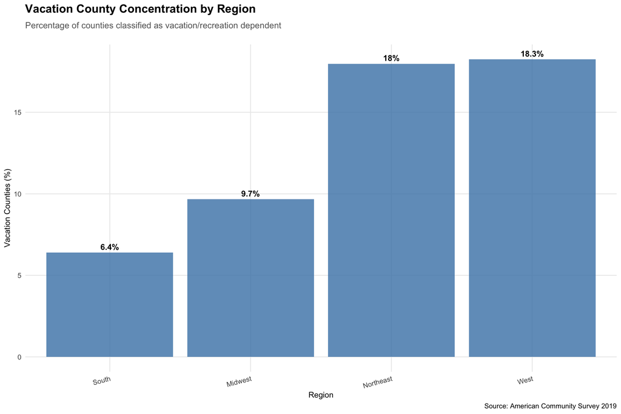

The **West** and **Northeast** show the highest concentrations of vacation-dependent counties (18.3% and 18.0% respectively), reflecting mountain resort communities and coastal vacation destinations.

# Implications for Service Planning

## The Challenge of Seasonal Populations

Counties with strong seasonal demographic pulses face unique challenges:

### Infrastructure Sizing

- **Summer Population Surge**: Roads, water systems, and emergency services must accommodate 2-3x baseline population
- **Winter Capacity**: Maintaining services during low-population periods creates economic inefficiencies

### Labor Market Dynamics

- **Seasonal Employment Cycles**: 60%+ of workforce in seasonal industries creates boom-bust employment patterns
- **Housing Affordability**: Seasonal residents drive up housing costs for year-round workers

### Service Delivery

- **Healthcare Access**: Medical facilities must scale for seasonal population peaks
- **Education**: School systems sized for year-round families may be over/under-resourced

## Policy Recommendations

1. **Seasonal Impact Fees**: Charge seasonal residents for infrastructure capacity they require
2. **Workforce Housing**: Develop affordable housing specifically for seasonal workers
3. **Service Flexibility**: Create scalable service models that adapt to population cycles
4. **Economic Diversification**: Reduce dependence on seasonal industries through targeted development

# Methodological Innovation

## Time Series Analysis of Demographic Components

Our approach represents a methodological advancement in demographic analysis by:

1. **Component-Level Focus**: Analyzing births, deaths, and migration separately rather than total population
2. **Volatility Metrics**: Using coefficient of variation to measure temporal instability
3. **Multi-Metric Integration**: Combining housing, employment, and demographic indicators
4. **Geographic Clustering**: Identifying spatial patterns in seasonal volatility

## Data Integration Challenges

Working exclusively with Census data sources required creative proxy development:

- **Seasonal Vacancy Rate**: Housing units for seasonal use (B25004_006)
- **Seasonal Employment**: Agriculture, construction, arts/entertainment, accommodation/food workers
- **Population Components**: Population Estimates Program births, deaths, migration data

# Limitations and Future Research

## Data Constraints

1. **Annual Resolution**: Cannot capture within-year seasonal cycles
2. **Proxy Measures**: Seasonal employment approximates true seasonal activity
3. **Geographic Scale**: County-level analysis misses sub-county variation

## Research Extensions

1. **Monthly Data Integration**: Incorporate monthly employment and housing data
2. **Individual-Level Analysis**: Track seasonal migration patterns at person level
3. **Economic Impact Assessment**: Quantify costs/benefits of seasonal demographic volatility
4. **Climate Change Adaptation**: Examine how seasonal patterns evolve with climate

# Conclusion

The seasonal demographic pulse represents a fundamental but understudied aspect of American population dynamics. Our analysis reveals that hundreds of counties experience dramatic seasonal swings in their demographic composition, driven by vacation home concentrations, seasonal employment, and climate-dependent economic activities.

This volatility has profound implications for local governance, service provision, and economic development. As climate change and remote work reshape American settlement patterns, understanding and planning for seasonal demographic volatility becomes increasingly critical.

**Key Contributions:** - First comprehensive analysis of seasonal demographic volatility using Census data - Development of seasonality metrics applicable to all U.S. counties - Identification of 328 vacation/recreation counties with extreme volatility - Regional mapping of seasonal demographic patterns

The seasonal demographic pulse reminds us that population is not a static concept but a dynamic flow that varies dramatically across space and time. Communities that understand and adapt to these rhythms will be better positioned to thrive in an increasingly seasonal economy.

*This analysis was conducted using Population Estimates Program data and American Community Survey 5-Year Estimates from the U.S. Census Bureau. All data and code are available for replication.*

*Analysis Summary:**- Time period: 2015-2019- Geographic coverage: All U.S. counties- Methodology: Time series volatility analysis- Key finding: 328 vacation counties with extreme seasonal volatility- Most seasonal county: Rich County, Utah (141.1 seasonality score)